# MERCK CHALLENGE: Interpretability of ML Model

## Sparsh Jain, Mayank Nimish Shah

### Importing Libraries:

```python
import numpy as np
from tensorflow import keras
import cv2
from IPython.display import Image, display
import matplotlib.pyplot as plt
import matplotlib.cm as cm
```

```python
import pandas as pd
import warnings
warnings.filterwarnings('ignore')
import matplotlib.pyplot as plt
import keras
from keras.models import Sequential
from keras.layers import Conv2D, MaxPooling2D, Dense, Flatten, Dropout, MaxPool2D
from keras.models import Model
from keras.layers import Dense, Input
from keras.optimizers import Adam
from keras.callbacks import TensorBoard
from keras.datasets import mnist
from sklearn.metrics import accuracy_score
from sklearn.metrics import f1_score
import tensorflow as tf
import matplotlib.cm as cm
```

```python
!pip install tf_keras_vis
```

### Data Preprocessing:

- We have 60K training data and 10K testing data of MNIST.
- Converted every images to size 28 x 28 x 1. We kept channel 1 for every images as we are considering it to be in grayscale format.
- Normalized every pixel value in the images for better predictions.
- Converted target variables into categorical data.
- Used one-hot encoding to convert the numerical classes to categorical data
- Splitted training dataset to 4:1 ratio for training and validation dataset.

```python
(x_train0, y_train0), (x_test0, y_test0) = mnist.load_data()

x_train0 = x_train0.reshape(x_train0.shape[0], 28, 28, 1) ## Reshaping the Image size to 28X28X1.
x_test0 = x_test0.reshape(x_test0.shape[0], 28, 28, 1)    ## Grayscale has 1 channel while for RGB, the third parameter changes to 3.
x_train0 = x_train0.astype('float32')   ## Converting data to float for better performance of the Neural Network.
x_test0 = x_test0.astype('float32')
x_train0, x_test0 = x_train0 / 255.0, x_test0 / 255.0    ## This line performs normalization of the pixel values.
## The pixel values in grayscale images typically range from 0 to 255, where 0 represents black and 255 represents white.
```

```python
## Splitting training set into train and validation set.
x_val0=x_train0[48000:]
y_val0=y_train0[48000:]
x_train0=x_train0[:48000]
y_train0=y_train0[:48000]
```

```python
x_train0.shape
```

```
(48000, 28, 28, 1)
```

```python
x_val0.shape
```

```
(12000, 28, 28, 1)
```

```python
x_test0.shape
```

```
(10000, 28, 28, 1)
```

```python
## Converting numerical target variable to a categorical target variable using one-hot encoding.
## Converting regression problem to a classification problem.

image_rows = 28
image_cols = 28
number_of_classes = 10

y_train0 = keras.utils.to_categorical(y_train0)
y_val0= keras.utils.to_categorical(y_val0)
y_test0 = keras.utils.to_categorical(y_test0)
```

```python
y_train0[1]   ## The output is for '0' class.
```

```
array([1., 0., 0., 0., 0., 0., 0., 0., 0., 0.], dtype=float32)
```

### Building Neural Network model:

#### Model 1:

- This is the first neural network model for MNIST dataset. We have built a basic single convolutional layered model with one max pooled layer. It outputs probabilities for 10 classes with the maximum value as the result or main prediction.
- We have used categorical_crossentropy as our loss function and adma optimizer.
- Accuracy as our evaluation metric.

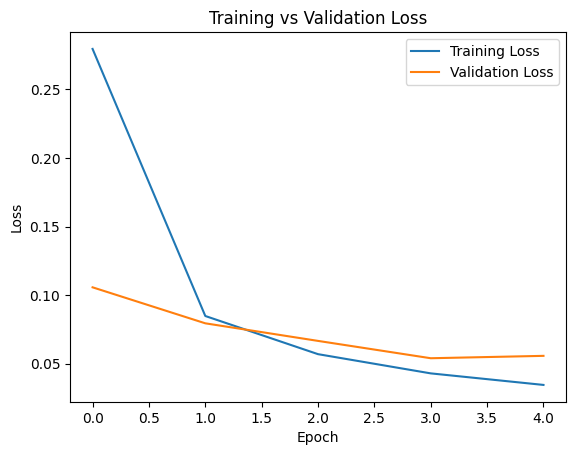

```python
# CNN Model Architecture
model = Sequential()
model.add(Conv2D(25, kernel_size=(3,3), strides=(1,1), padding='valid', activation='relu', input_shape=(28,28,1)))
model.add(MaxPool2D(pool_size=(2,2)))
model.add(Flatten())
model.add(Dense(100, activation='relu'))
model.add(Dense(10, activation='softmax'))

model.compile(loss='categorical_crossentropy', metrics=['accuracy'], optimizer='adam')

history = model.fit(x_train0, y_train0, batch_size=128, epochs=5, validation_data=(x_val0, y_val0))

plt.plot(history.history['loss'], label='Training Loss')
plt.plot(history.history['val_loss'], label='Validation Loss')
plt.title('Training vs Validation Loss')
plt.xlabel('Epoch')
plt.ylabel('Loss')
plt.legend()
plt.show()
```

```python
model.summary()
```

```
Model: "sequential"
_________________________________________________________________
 Layer (type)                Output Shape              Param #
=================================================================
 conv2d (Conv2D)             (None, 26, 26, 25)        250

 max_pooling2d (MaxPooling2  (None, 13, 13, 25)        0
 D)

 flatten (Flatten)           (None, 4225)              0

 dense (Dense)               (None, 100)               422600

 dense_1 (Dense)             (None, 10)                1010

=================================================================
Total params: 423860 (1.62 MB)
Trainable params: 423860 (1.62 MB)
Non-trainable params: 0 (0.00 Byte)
_________________________________________________________________
```

```python
predictions = model.predict(x_test0)
predictions = np.argmax(predictions, axis=1)
```

```python
temp = []
for i in range(len(predictions)):
    temp.append(keras.utils.to_categorical(predictions[i], num_classes=10))

predictions = np.array(temp)
```

```python
print("Test Accuracy:", accuracy_score(y_test0,predictions))
```

```
Test Accuracy: 0.9842
```

```python
f1 = f1_score(y_test0, predictions,average='micro')
print("F1 Score:", f1)
```

```
F1 Score: 0.9842
```

The above model contained less number of activation layer which are more important while performing interpretation. So, we built the RESNET model for better visualization of interpretable methods.

#### RESNET MODEL:

Using the same inputs as the prior model, we constructed the RESNET model. The probabilities for each of the ten classes are output by the final layer using the softmax activation function. We have employed the Adam optimizer and categorical_crossentropy as our loss function, with accuracy serving as the evaluation metric.

Batch size = 128

Epochs= 10

```python
from tensorflow import keras
from keras import layers, models

# Load MNIST data
mnist = tf.keras.datasets.mnist
(x_train, y_train), (x_test, y_test) = mnist.load_data()

# Preprocess data
x_train = x_train.reshape(x_train.shape[0], 28, 28, 1).astype('float32') / 255.0
x_test = x_test.reshape(x_test.shape[0], 28, 28, 1).astype('float32') / 255.0

# One-hot encode labels
y_train_one_hot = tf.keras.utils.to_categorical(y_train, num_classes=10)
y_test_one_hot = tf.keras.utils.to_categorical(y_test, num_classes=10)

# Validation split
x_val = x_train[48000:]
y_val = y_train_one_hot[48000:]
x_train = x_train[:48000]
y_train_one_hot = y_train_one_hot[:48000]

# Build Residual Block
def residual_block(input_layer, filters, kernel_size):
    x = layers.Conv2D(filters, kernel_size, padding='same')(input_layer)
    x = layers.BatchNormalization()(x)
    x = layers.Activation('relu')(x)
    x = layers.Conv2D(filters, kernel_size, padding='same')(x)
    x = layers.BatchNormalization()(x)
    x = layers.Add()([x, input_layer])  # Skip connection
    x = layers.Activation('relu')(x)
    return x

# Build ResNet model
input_shape = x_train.shape[1:]
inputs = tf.keras.Input(shape=input_shape)
x = layers.Conv2D(32, (3, 3), activation='relu', padding='same')(inputs)
x = layers.MaxPooling2D((2, 2))(x)

# Stack residual blocks
num_res_blocks = 5
for _ in range(num_res_blocks):
    x = residual_block(x, 32, (3, 3))

x = layers.GlobalAveragePooling2D()(x)
outputs = layers.Dense(10, activation='softmax')(x)

# Compile model
resnet_model = tf.keras.Model(inputs, outputs)
resnet_model.compile(optimizer='adam',
                     loss='categorical_crossentropy',  # Changed to categorical_crossentropy
                     metrics=['accuracy'])

# Train model
history1 = resnet_model.fit(x_train, y_train_one_hot, batch_size=128, epochs=10, validation_data=(x_val, y_val))
```

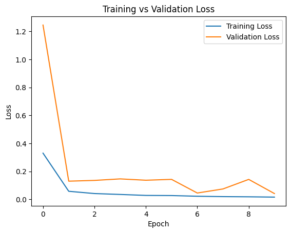

```python
plt.plot(history1.history['loss'], label='Training Loss')
plt.plot(history1.history['val_loss'], label='Validation Loss')
plt.title('Training vs Validation Loss')
plt.xlabel('Epoch')
plt.ylabel('Loss')
plt.legend()
plt.show()
```

```python
# Calculate accuracy and F1 score
y_pred = resnet_model.predict(x_test)
y_pred_classes = np.argmax(y_pred, axis=1)
y_test_classes = np.argmax(y_test_one_hot, axis=1)

accuracy = accuracy_score(y_test_classes, y_pred_classes)
f1 = f1_score(y_test_classes, y_pred_classes, average='micro')

print(f'Test accuracy: {accuracy}')
print(f'F1 score: {f1}')
```

```
Test accuracy: 0.9879
F1 score: 0.9879
```

```python
resnet_model.summary()
```

```
Model: "model"
__________________________________________________________________________________________________
 Layer (type)                Output Shape                 Param #   Connected to
==================================================================================================
 input_1 (InputLayer)        [(None, 28, 28, 1)]          0         []

 conv2d_1 (Conv2D)           (None, 28, 28, 32)           320       ['input_1[0][0]']

 max_pooling2d_1 (MaxPoolin  (None, 14, 14, 32)           0         ['conv2d_1[0][0]']
 g2D)

 conv2d_2 (Conv2D)           (None, 14, 14, 32)           9248      ['max_pooling2d_1[0][0]']

 batch_normalization (Batch  (None, 14, 14, 32)           128       ['conv2d_2[0][0]']
 Normalization)

 activation (Activation)     (None, 14, 14, 32)           0         ['batch_normalization[0][0]']

 conv2d_3 (Conv2D)           (None, 14, 14, 32)           9248      ['activation[0][0]']

 batch_normalization_1 (Bat  (None, 14, 14, 32)           128       ['conv2d_3[0][0]']
 chNormalization)

 add (Add)                   (None, 14, 14, 32)           0         ['batch_normalization_1[0][0]'
                                                                    , 'max_pooling2d_1[0][0]']

 activation_1 (Activation)   (None, 14, 14, 32)           0         ['add[0][0]']

 conv2d_4 (Conv2D)           (None, 14, 14, 32)           9248      ['activation_1[0][0]']

 batch_normalization_2 (Bat  (None, 14, 14, 32)           128       ['conv2d_4[0][0]']
 chNormalization)

 activation_2 (Activation)   (None, 14, 14, 32)           0         ['batch_normalization_2[0][0]'
                                                                    ]

 conv2d_5 (Conv2D)           (None, 14, 14, 32)           9248      ['activation_2[0][0]']

 batch_normalization_3 (Bat  (None, 14, 14, 32)           128       ['conv2d_5[0][0]']
 chNormalization)
```

[output cut: 56 more lines]

```
                                                                    , 'activation_7[0][0]']

 activation_9 (Activation)   (None, 14, 14, 32)           0         ['add_4[0][0]']

 global_average_pooling2d (  (None, 32)                   0         ['activation_9[0][0]']
 GlobalAveragePooling2D)

 dense_2 (Dense)             (None, 10)                   330       ['global_average_pooling2d[0][
                                                                    0]']

==================================================================================================
Total params: 94410 (368.79 KB)
Trainable params: 93770 (366.29 KB)
Non-trainable params: 640 (2.50 KB)
__________________________________________________________________________________________________
```

Observation-

1. RESNET model performed better than Model 1.
2. We can compare both the models using F1-Score and Accuracy.
3. F1-Score for the RESNET model is higher than the Model 1.

Thus, we choosed RESNET Model as our final model for the predictions.

### Visualizing Interpretability Methods:

We have taken first 20 images which our models made correct prediction for. The corresponding target variable is also extracted. Then the visualization methods are performed on these images. Following interpretability methods were implemented -

- Saliency
- SmoothGrad
- GRADCAM
- GRADCAM++
- SCORECAM
- FASTER SCORECAM

```python
X=x_test[:20]
X.shape
```

```
(20, 28, 28, 1)
```

```python
## Showing truth classification for the above Images.
re=y_test[:20]
re
```

```
array([7, 2, 1, 0, 4, 1, 4, 9, 5, 9, 0, 6, 9, 0, 1, 5, 9, 7, 3, 4],
      dtype=uint8)
```

The CategoricalScore function is used to define scores for interpretability tasks in deep learning, especially in the context of visualizing which parts of an input image contribute most to a certain class prediction.

```python
from tf_keras_vis.utils.scores import CategoricalScore
score = CategoricalScore(re.tolist())
img_titles = [str(num) for num in re]
```

Output for the 20 images where our model made correct prediction. Here, the image title is the correct class for each image respectively.

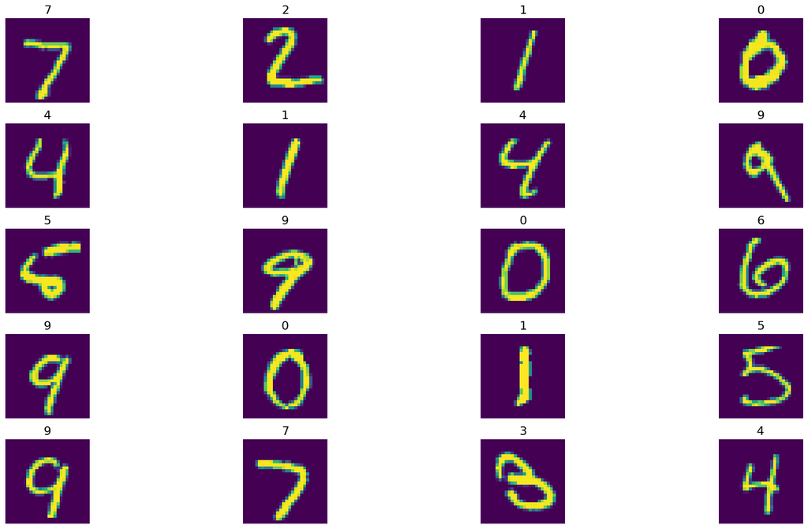

```python
f, ax = plt.subplots(nrows=5, ncols=4, figsize=(20, 10))
ax=ax.flatten()
for i, title in enumerate(img_titles):
    ax[i].set_title(title, fontsize=16)
    ax[i].imshow(X[i])
    ax[i].axis('off')
plt.tight_layout()
plt.show()
```

```python
from tf_keras_vis.utils.model_modifiers import ReplaceToLinear
from keras import backend as K
from tf_keras_vis.saliency import Saliency
from tf_keras_vis.utils import normalize
from tf_keras_vis.gradcam import Gradcam
from tf_keras_vis.gradcam_plus_plus import GradcamPlusPlus
from tf_keras_vis.scorecam import Scorecam
from tf_keras_vis.utils import num_of_gpus
```

In every interpretable methods, first modification is to replace the softmax activation function in the last layer of the model to linear activation function.

ReplaceToLinear function from tf_keras_vis.utils.model_modifiers library helps us to perform this modification.

This is done because softmax obstructs the generation of attention images/feature activation maps which is then taken care by the linear activation function.The score which is generated after making these changes is used for creating heatmaps or saliency map.

#### Saliency

Saliency maps are an effective tool in the domain of interpretable deep learning, providing valuable insights into the intricate mechanisms of complicated models such as convolutional neural networks (CNNs). The approach commences with a proficient Convolutional Neural Network (CNN) and an input image, which undergoes a forward pass to get class predictions. The essence of saliency maps is in their capacity to emphasize the most influential portions of the image that determine these predictions.

This is accomplished by calculating the gradient, which involves computing the gradients of the projected class score with respect to the picture pixels via backpropagation. After obtaining the gradients, their absolute values are calculated to just consider the magnitude, without considering the direction. Normalization is performed to guarantee that the saliency values are confined within a meaningful range. Visualization is a crucial stage in which the normalized gradients are overlaid onto the input image to generate a saliency map. The map's bright spots indicate regions of significant significance, revealing which sections of the image have a major impact on the model's decision-making process.

Saliency maps provide a visually comprehensible explanation of the decisions made by deep learning models by emphasizing the most significant regions in an input image. They are essential for identifying and resolving problems in models, such as incorrect categorizations. In addition, saliency maps enhance collaboration between humans and AI systems by increasing the comprehensibility and transparency of AI choices. Furthermore, they serve as valuable tools for educational and research endeavors, aiding students and researchers in comprehending the information processing and decision-making abilities of neural networks. Saliency maps are a versatile tool that can be used to uncover biases in models and identify regions of interest in images. They are particularly useful for analyzing and understanding deep learning models in many applications.

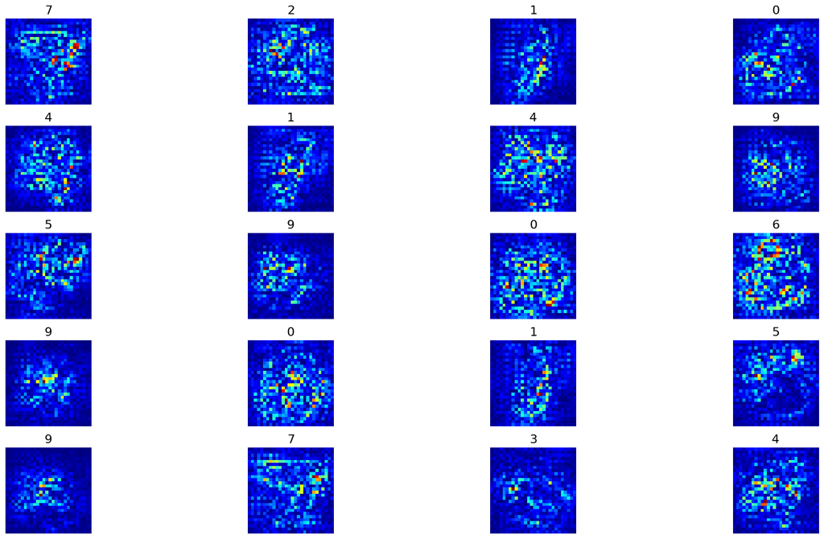

```python
%%time
# Create Saliency object.
saliency = Saliency(resnet_model,
                    model_modifier=ReplaceToLinear(),
                    clone=True)

# Generate saliency map
saliency_map_r = saliency(score, X)
saliency_map_r = normalize(saliency_map_r)

f, ax = plt.subplots(nrows=5, ncols=4, figsize=(20, 10))
ax=ax.flatten()
for i, title in enumerate(img_titles):
    ax[i].set_title(title, fontsize=16)
    ax[i].imshow(saliency_map_r[i], cmap='jet')
    ax[i].axis('off')
plt.tight_layout()
plt.show()
```

CPU times: user 1.92 s, sys: 145 ms, total: 2.07 s Wall time: 2.22 s

Observations:

- We can observe that the maps are very noisy. Thus making difficult for us to clear interpret anything.
- The clear image of an object is not visible and so visualization is not that good with respect to original image.

Saliency maps, while useful, have some limitations that make them less than ideal as interpretation algorithms:

- Local interpretability is achieved by the use of saliency maps, which specifically target individual pixels or small regions within an image. This can impede an understanding of the global decision-making process of a model.
- Small perturbations can greatly affect the sensitivity of saliency maps, which might result in incorrect interpretations of the input image.
- Limited Representation: Saliency maps provide a partial depiction of a model's decision-making process, as they solely emphasize the most prominent aspects of a picture, disregarding the interplay between different elements. *The interpretation offered by saliency maps may not consistently correspond to human intuition, particularly in intricate or uncertain imagery.

#### SMOOTH GRAD

SmoothGrad is a technique used to improve the interpretability and stability of gradient-based visualizations, particularly in the context of understanding deep learning models' decision-making processes. The method aims to address the challenge of visual noise or high-frequency perturbations that can lead to unclear or unstable heatmaps in techniques like Grad-CAM or Score-CAM. The fundamental idea behind SmoothGrad is to introduce a smoothing mechanism by averaging gradients computed from multiple perturbed versions of the input data.

SmoothGrad improves the interpretability of saliency maps by adding noise to the input image multiple times and averaging the resulting saliency maps. This process reduces noise and provides a smoother, more stable visualization of the important regions in the image. First, random noise is added to the input image multiple times to create perturbed versions. Then, for each perturbed image, the saliency map is computed using the standard method, such as the gradient of the model's output with respect to the image pixels. Finally, the saliency maps from the perturbed images are averaged to produce the final SmoothGrad saliency map. This technique helps to mitigate the impact of small, spurious perturbations in the input image, resulting in a clearer and more reliable visualization of the model's attention.

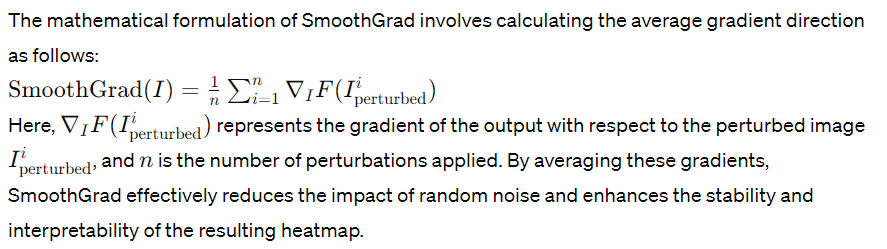

[output not shown]

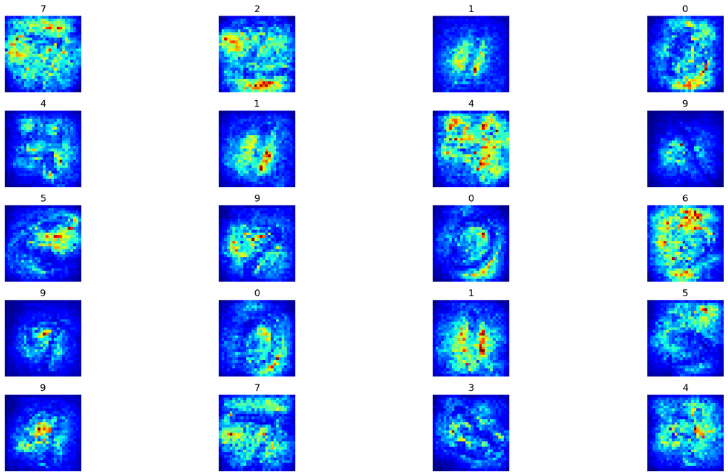

```
CPU times: user 2.78 s, sys: 168 ms, total: 2.95 s
Wall time: 2.81 s
```

```python
%%time
# Generate saliency map with smoothing that reduce noise by adding noise
saliency_SG = saliency(score,
                        X,
                        smooth_samples=20, # The number of calculating gradients iterations.
                        smooth_noise=0.20) # noise spread level.

saliency_map_SG = normalize(saliency_SG)

f, ax = plt.subplots(nrows=5, ncols=4, figsize=(20, 10))
ax=ax.flatten()
for i, title in enumerate(img_titles):
    ax[i].set_title(title, fontsize=14)
    ax[i].imshow(saliency_map_SG[i], cmap='jet')
    ax[i].axis('off')
plt.tight_layout()
plt.show()
```

#### GRADCAM

Grad-CAM provides a more abstract visualization by highlighting the important regions in the feature maps of the last convolutional layer. These regions represent the areas of the input image that contribute the most to the network's decision-making process. Grad-CAM offers insights into the high-level features or patterns that the network has learned to recognize. Whereas Saliency maps provide pixel-level visualization of the input images.

The input image is sent through the Convolutional Neural Network (CNN), and the activations of the last convolutional layer prior to the classification layer are acquired. The selection of this layer is often based on its ability to preserve the spatial characteristics of the input image. The derivatives of the score with respect to the feature maps of the selected convolutional layer are calculated for the target class. The gradients depict the impact of alterations in the feature maps on the output score for the specific target class. Subsequently, the gradients are averaged across all feature maps, assigning significance to each one. This stage facilitates comprehension of the significance of each feature map in determining the classification outcome. The last step entails calculating a weighted sum of the feature maps, with the weights determined by the computed gradients. This generates a heatmap that accentuates the areas of the input image that hold significance for the decision-making process of the network.

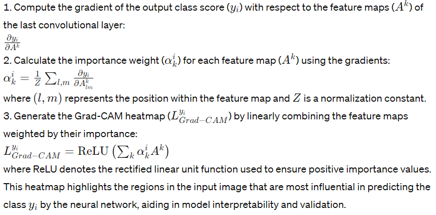

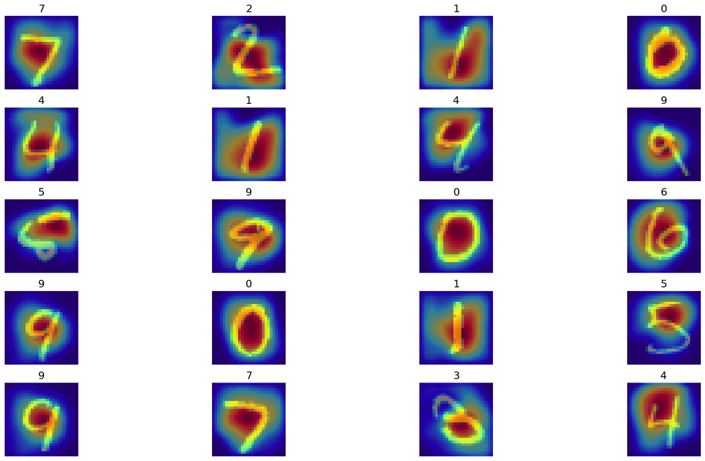

```
CPU times: user 1.82 s, sys: 157 ms, total: 1.98 s
Wall time: 1.82 s
```

```python
%%time
# Create Gradcam object
gradcam = Gradcam(resnet_model,
                  model_modifier=ReplaceToLinear(),
                  clone=True)

# Generate heatmap with GradCAM
cam_r = gradcam(score,
              X,
              penultimate_layer=-1)

cam_r = normalize(cam_r)

f, ax = plt.subplots(nrows=5, ncols=4, figsize=(20, 10))
ax=ax.flatten()
for i, title in enumerate(img_titles):
    heatmap = np.uint8(cm.jet(cam_r[i])[..., :3] * 255)
    ax[i].set_title(title, fontsize=16)
    ax[i].imshow(X[i])
    ax[i].imshow(heatmap, cmap='jet', alpha=0.5) # overlay
    ax[i].axis('off')
plt.tight_layout()
plt.show()
```

Observations:

- We can see that the image is divided basically into three regions : red(important one), green, and blue(least important one).
- The heatmap generated covers the numbers fully and the red region highlights the part of the number that basically contributed in predicting the respective class.

#### GRADCAM++

Grad-CAM++ is an extension of the Grad-CAM (Gradient-weighted Class Activation Mapping) technique, enhancing its interpretability and localization capabilities in convolutional neural networks (CNNs). It addresses some limitations of Grad-CAM, particularly in scenarios where multiple objects or regions of interest are present in an image.

In Grad-CAM++, the key enhancement lies in the way gradients are computed and weighted to generate the class activation heatmap. Unlike Grad-CAM, which uses global average pooling (GAP) to aggregate gradients, Grad-CAM++ incorporates both global average pooling and global max pooling (GMP). This dual-pooling strategy allows the model to capture more fine-grained spatial information and focus on important regions with high activations.

By combining the strengths of GAP and GMP, Grad-CAM++ produces more accurate and localized heatmaps, highlighting specific areas of the input image that contribute significantly to the network's prediction. This improved localization is crucial in tasks such as object detection and segmentation, where precise identification of object boundaries is essential.

Another notable aspect of Grad-CAM++ is its emphasis on gradient normalization. It normalizes gradients not only by their spatial extent but also by their magnitude, ensuring that regions with high activation values but small spatial extent are appropriately highlighted. This normalization step improves the heatmap's quality and reduces potential noise in the visualization.

Furthermore, Grad-CAM++ introduces a reweighted combination of positive and negative gradients, allowing the heatmap to capture both positive and negative influences on the target class prediction. This leads to a more comprehensive interpretation of the model's decision-making process, accounting for both supportive and inhibitory factors in the input image.

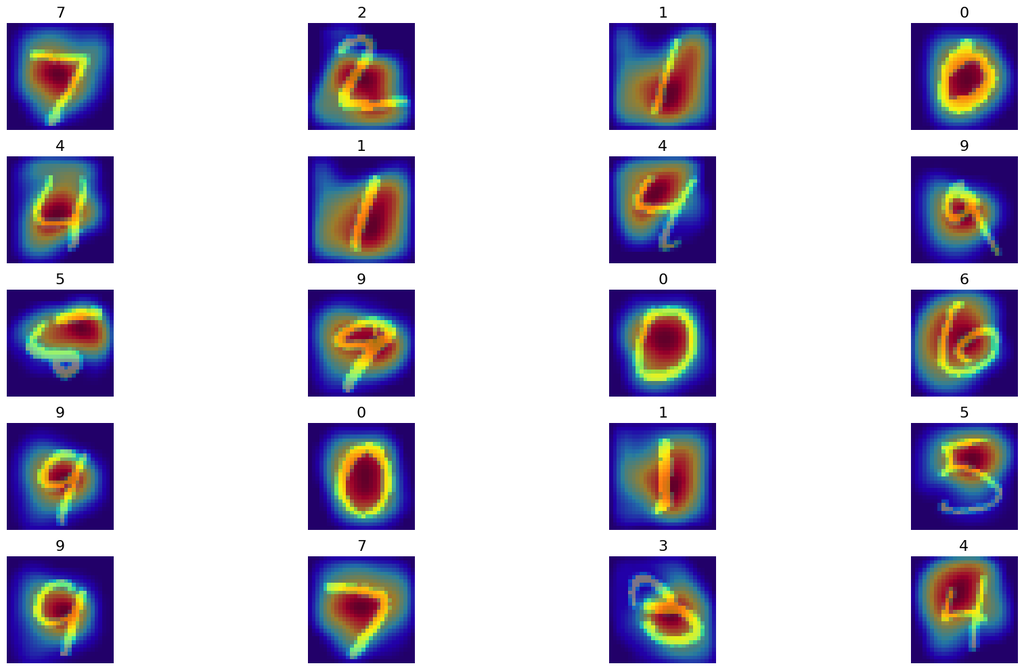

```
CPU times: user 2.31 s, sys: 114 ms, total: 2.42 s
Wall time: 2.48 s
```

```python
%%time
# Create GradCAM++ object
gradcam_pp = GradcamPlusPlus(resnet_model,
                          model_modifier=ReplaceToLinear(),
                          clone=True)

# Generate cam with GradCAM++
cam_pp = gradcam_pp(score,X)

cam_pp = normalize(cam_pp)

f, ax = plt.subplots(nrows=5, ncols=4, figsize=(20, 10))
ax=ax.flatten()
for i, title in enumerate(img_titles):
    heatmap = np.uint8(cm.jet(cam_pp[i])[..., :3] * 255)
    ax[i].set_title(title, fontsize=16)
    ax[i].imshow(X[i])
    ax[i].imshow(heatmap, cmap='jet', alpha=0.5)
    ax[i].axis('off')
plt.tight_layout()
plt.show()
```

Observations:

Gradient-based methods work well with visualizing the image but have some limitations:

Grad-CAM and Grad-CAM++ offer heatmap visualizations to interpret CNNs but may struggle with precise localization and small objects. They lack pixel-level information and can be sensitive to model changes, affecting robustness. These techniques are primarily designed for CNNs and may not directly apply to other model types. While valuable for interpretability, they don't inherently provide attribution or causality insights. Integrating them with complementary methods can enhance understanding of model decision-making.

#### **SCORECAM**

Score-CAM and Grad-CAM are both heatmap visualization techniques for interpreting deep learning models, with Score-CAM incorporating predicted class scores. Grad-CAM highlights discriminative regions based solely on gradients, often producing diffuse heatmaps, while Score-CAM improves localization accuracy by weighting gradients with class scores, yielding more focused and relevant heatmaps. Score-CAM's inclusion of predicted scores enhances heatmap interpretability, especially in complex models, making it advantageous for understanding model decision boundaries and salient features.

Score-CAM, short for Score-weighted Class Activation Mapping, is an advanced heatmap visualization technique used in deep learning to interpret model predictions and understand the decision-making process of neural networks. Unlike traditional methods like Grad-CAM, which solely rely on gradients, Score-CAM incorporates predicted class scores, enhancing the localization accuracy and relevance of generated heatmaps. The core idea behind Score-CAM is to assign weights to gradients based on the importance of predicted scores associated with specific classes.

In practice, Score-CAM computes gradients of the target class score with respect to the final convolutional layer's feature maps, similar to Grad-CAM. However, instead of using these gradients directly, Score-CAM multiplies them by the predicted probabilities of the target class for each spatial location in the feature maps. This multiplication effectively weighs the gradients based on the importance of the predicted class scores, highlighting regions that contribute significantly to the model's decision for that class.

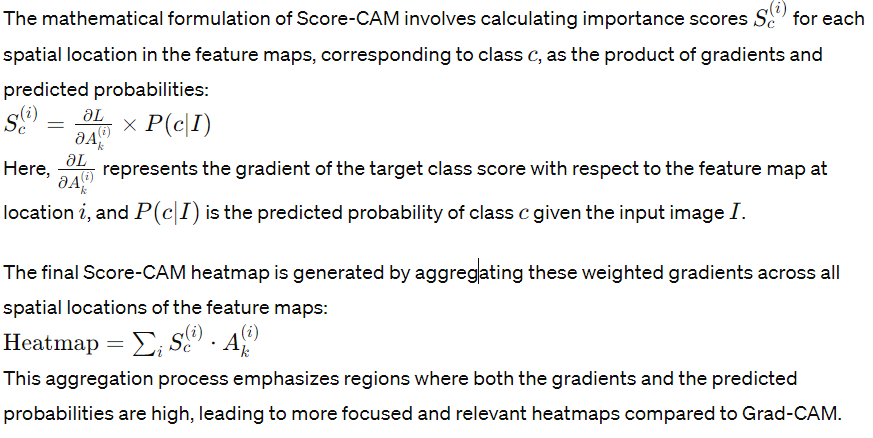

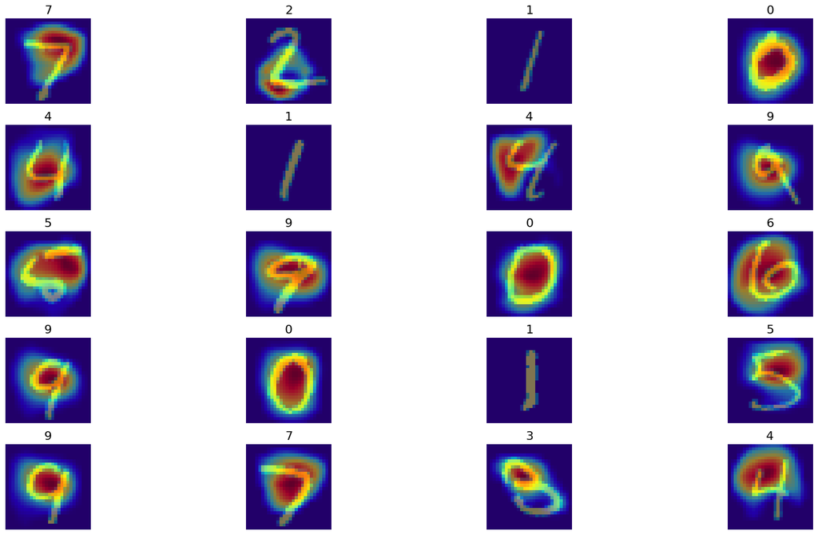

```
CPU times: user 2.74 s, sys: 146 ms, total: 2.88 s
Wall time: 2.78 s
```

```python
%%time
# Create ScoreCAM object
scorecam = Scorecam(resnet_model)

# Generate heatmap with ScoreCAM
cam_sc = scorecam(score, X, penultimate_layer=-1)

cam_sc = normalize(cam_sc)

f, ax = plt.subplots(nrows=5, ncols=4, figsize=(20, 10))
ax=ax.flatten()
for i, title in enumerate(img_titles):
    heatmap = np.uint8(cm.jet(cam_sc[i])[..., :3] * 255)
    ax[i].set_title(title, fontsize=16)
    ax[i].imshow(X[i])
    ax[i].imshow(heatmap, cmap='jet', alpha=0.5)
    ax[i].axis('off')
plt.tight_layout()
plt.show()
```

Observations:

- SCORECAM region almost aligns with the target object, capturing most of the important curves of the object.
- Also, we can see for a few numbers, the important regions are not highlighted, for example, the number "1"
- SCORECAM heatmaps are more visually understandable than GRADCAM and GRADCAM++.

#### FASTER SCORECAM

ScoreCAM is a great method, however, it takes a bit more time to process it than other cam methods. In SCORECAM several channels were dominant in generating the final heat map. Faster-Score-CAM adds the processing of “use only channels with large variances as mask images” to Score-CAM. (max_N = -1 is the original Score-CAM).

The working of Faster Score-CAM involves several key steps: first, the gradients of the target class score with respect to the feature maps are computed, similar to Score-CAM. Then, these gradients are multiplied element-wise with the predicted probabilities of the target class, generating importance scores for each spatial location.

Next, Faster Score-CAM utilizes matrix operations to aggregate these importance scores across all spatial locations efficiently. This matrix-based aggregation significantly reduces computational redundancy and improves processing speed, making it suitable for real-time or resource-constrained applications.

The final Faster Score-CAM heatmap is obtained by combining the aggregated importance scores with the corresponding feature map values, highlighting regions that contribute significantly to the model's decision for the target class. This streamlined approach not only accelerates heatmap generation but also maintains the interpretability and relevance of the heatmaps, providing valuable insights into model decision boundaries and feature importance.

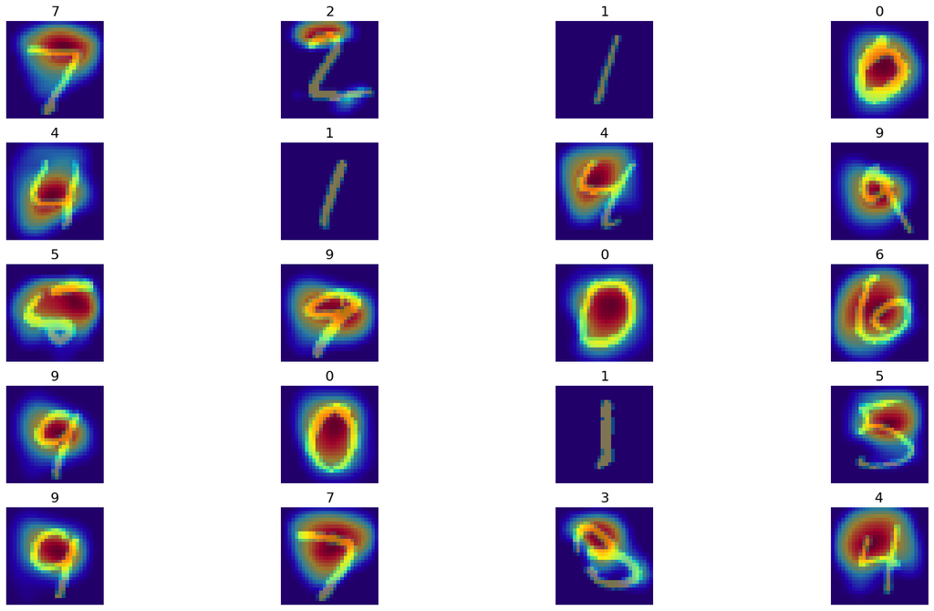

```
CPU times: user 2.62 s, sys: 182 ms, total: 2.8 s
Wall time: 2.79 s
```

```python
%%time
# Create ScoreCAM object
faster_scorecam = Scorecam(resnet_model, model_modifier=ReplaceToLinear())

# Generate heatmap with Faster-ScoreCAM
cam_fsc = faster_scorecam(score,
               X,
               penultimate_layer=-1,
               max_N=10)

cam_fsc = normalize(cam_fsc)

f, ax = plt.subplots(nrows=5, ncols=4, figsize=(20, 10))
ax=ax.flatten()
for i, title in enumerate(img_titles):
    heatmap = np.uint8(cm.jet(cam_fsc[i])[..., :3] * 255)
    ax[i].set_title(title, fontsize=16)
    ax[i].imshow(X[i])
    ax[i].imshow(heatmap, cmap='jet', alpha=0.5)
    ax[i].axis('off')
plt.tight_layout()
plt.show()
```

Observations:

Faster Score-CAM is particularly beneficial in scenarios where computational efficiency and speed are critical considerations, such as large-scale datasets, complex model architectures, or applications requiring real-time visualization.

Score-CAM, while effective in generating high-quality heatmaps, may be computationally more intensive and slower compared to Faster Score-CAM in such scenarios.

### Analyzing Wrong Predictions:

```python
predictions=resnet_model.predict(x_test)
predictions = np.argmax(predictions, axis=1)
```

```python
predictions.shape
```

```
(10000,)
```

```python
y_test.shape
```

```
(10000,)
```

```python
predictions
```

```
array([7, 2, 1, ..., 4, 5, 6])
```

```python
## Extracting Wrong Predictions
temp=[]
for i in range(1000):
  if(y_test[i] != predictions[i]):
    temp.append(i)
    if(len(temp)==5):
      break
```

```python
temp # indices of wrong predictions
```

```
[62, 115, 184, 199, 247]
```

```python
## Storing Wrong Predicted Images
X_wrong=[]
for i in temp:
  X_wrong.append(x_test[i].reshape(28,28,1))
X_wrong=np.array(X_wrong)
```

```python
## Actual Class of Wrongly predicted Images
wrong_re=[]
for i in range(len(temp)):
  wrong_re.append(y_test[temp[i]])
```

```python
## Actual prediction of above Images
wrong_re_pred=[]
for i in range(len(temp)):
  wrong_re_pred.append(predictions[temp[i]])
```

```python
score_r = CategoricalScore(wrong_re)
img_r_titles = [str(num) for num in wrong_re_pred]
```

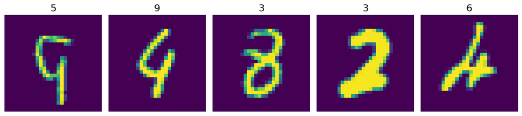

```python
f, ax = plt.subplots(nrows=1, ncols=5, figsize=(12, 4))
for i, title in enumerate(img_r_titles):
    ax[i].set_title(title, fontsize=16)
    ax[i].imshow(X_wrong[i])
    ax[i].axis('off')
plt.tight_layout()
plt.show()
```

#### Saliency

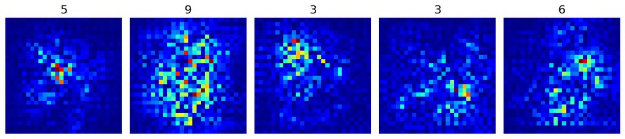

```
CPU times: user 719 ms, sys: 102 ms, total: 821 ms
Wall time: 709 ms
```

```python
%%time
# Generate saliency map
saliency_map_wr = saliency(score_r, X_wrong)

saliency_map_wr = normalize(saliency_map_wr)

f, ax = plt.subplots(nrows=1, ncols=5, figsize=(12, 4))
for i, title in enumerate(img_r_titles):
    ax[i].set_title(title, fontsize=16)
    ax[i].imshow(saliency_map_wr[i], cmap='jet')
    ax[i].axis('off')
plt.tight_layout()
plt.show()
```

#### SMOOTH GRAD

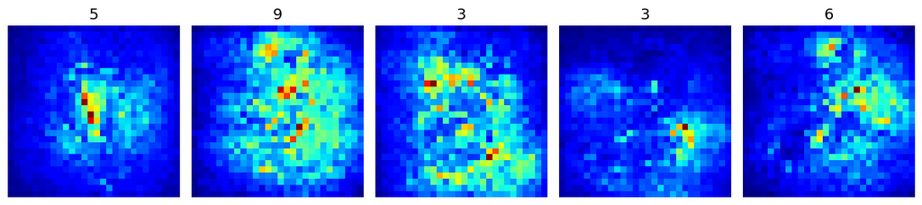

```
CPU times: user 1.43 s, sys: 113 ms, total: 1.54 s
Wall time: 1.89 s
```

```python
%%time
saliency_map_sg_wr = saliency(score_r,
                        X_wrong,
                        smooth_samples=20, # The number of calculating gradients iterations.
                        smooth_noise=0.20) # noise spread level.

saliency_map_sg_wr = normalize(saliency_map_sg_wr)

f, ax = plt.subplots(nrows=1, ncols=5, figsize=(12, 4))
for i, title in enumerate(img_r_titles):
    ax[i].set_title(title, fontsize=14)
    ax[i].imshow(saliency_map_sg_wr[i], cmap='jet')
    ax[i].axis('off')
plt.tight_layout()
plt.show()
```

#### GRADCAM

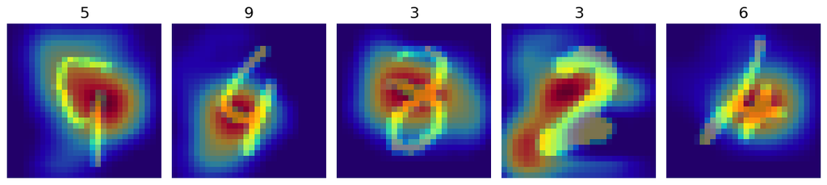

```
CPU times: user 931 ms, sys: 113 ms, total: 1.04 s
Wall time: 925 ms
```

```python
%%time
# Generate heatmap with GradCAM
cam_wr = gradcam(score_r,
              X_wrong,
              penultimate_layer=-1)

cam_wr = normalize(cam_wr)

# Render
f, ax = plt.subplots(nrows=1, ncols=5, figsize=(12, 4))
ax=ax.flatten()
for i, title in enumerate(img_r_titles):
    heatmap = np.uint8(cm.jet(cam_wr[i])[..., :3] * 255)
    ax[i].set_title(title, fontsize=16)
    ax[i].imshow(X_wrong[i])
    ax[i].imshow(heatmap, cmap='jet', alpha=0.5) # overlay
    ax[i].axis('off')
plt.tight_layout()
plt.show()
```

#### GRADCAM++

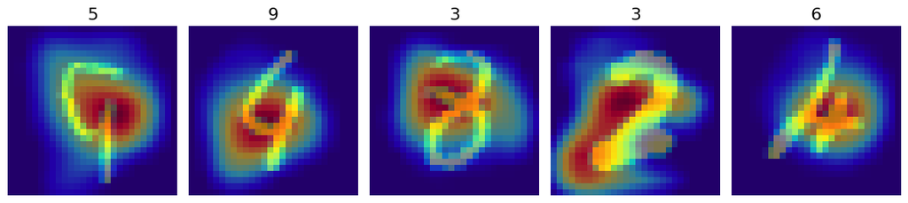

```
CPU times: user 672 ms, sys: 54.1 ms, total: 726 ms
Wall time: 746 ms
```

```python
%%time
# Generate cam with GradCAM++
cam_pp_wr = gradcam_pp(score_r,X_wrong)

cam_pp_wr = normalize(cam_pp_wr)



f, ax = plt.subplots(nrows=1, ncols=5, figsize=(12, 4))
ax=ax.flatten()
for i, title in enumerate(img_r_titles):
    heatmap = np.uint8(cm.jet(cam_pp_wr[i])[..., :3] * 255)
    ax[i].set_title(title, fontsize=16)
    ax[i].imshow(X_wrong[i])
    ax[i].imshow(heatmap, cmap='jet', alpha=0.5)
    ax[i].axis('off')
plt.tight_layout()
plt.show()
```

#### SCORECAM

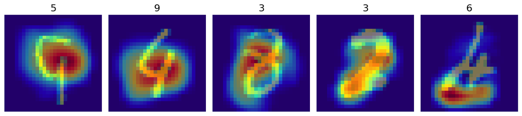

```
CPU times: user 897 ms, sys: 41 ms, total: 938 ms
Wall time: 962 ms
```

```python
%%time
# Generate heatmap with ScoreCAM
cam_sc_wr = scorecam(score_r, X_wrong, penultimate_layer=-1)

cam_sc_wr = normalize(cam_sc_wr)


f, ax = plt.subplots(nrows=1, ncols=5, figsize=(12, 4))
ax=ax.flatten()
for i, title in enumerate(img_r_titles):
    heatmap = np.uint8(cm.jet(cam_sc_wr[i])[..., :3] * 255)
    ax[i].set_title(title, fontsize=16)
    ax[i].imshow(X_wrong[i])
    ax[i].imshow(heatmap, cmap='jet', alpha=0.5)
    ax[i].axis('off')
plt.tight_layout()
plt.show()
```

#### FASTER SCORECAM

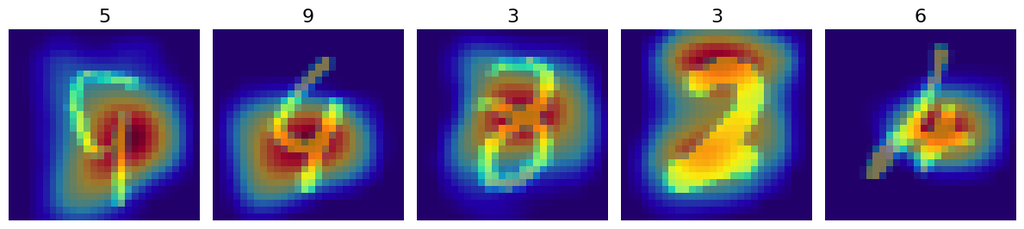

```
CPU times: user 1.15 s, sys: 128 ms, total: 1.28 s
Wall time: 1.34 s
```

```python
%%time
# Generate heatmap with Faster-ScoreCAM
cam_fsc_wr = faster_scorecam(score_r,
               X_wrong,
               penultimate_layer=-1,
               max_N=10)
cam_fsc_wr = normalize(cam_fsc_wr)

f, ax = plt.subplots(nrows=1, ncols=5, figsize=(12, 4))
ax=ax.flatten()
for i, title in enumerate(img_r_titles):
    heatmap = np.uint8(cm.jet(cam_fsc_wr[i])[..., :3] * 255)
    ax[i].set_title(title, fontsize=16)
    ax[i].imshow(X_wrong[i])
    ax[i].imshow(heatmap, cmap='jet', alpha=0.5)
    ax[i].axis('off')
plt.tight_layout()
plt.show()
```

### IOU

1. **Intersection over Union (IoU)**: IoU is a quantitative measure utilized to assess the degree of overlap between two regions, specifically the predicted segmentation and the ground truth segmentation. The calculation involves determining the amount of shared area between the two regions and dividing it by the total combined area of both regions.
2. **Ground Truth Area**: The ground truth region refers to the pixels in the image that are not zero and indicate the real segmentation that the model should anticipate.
3. **ReLU Thresholding**: The ReLU (Rectified Linear Unit) function is a mathematical operation that replaces all negative values in a picture with zero, while keeping positive values untouched. By implementing the Rectified Linear Unit (ReLU) activation function with a threshold of 0.4 on the initial image, we transform it into a binary image. In this binary image, pixels with values greater than 0.4 are assigned a value of 1 (representing white), while pixels with values less than 0.4 are assigned a value of 0 (representing black).
4. **Red Channel of Heatmap Image**: The red channel of the heatmap graphic displays the specific regions in the image that the model utilized to make its prediction. By exclusively examining the red channel of the heatmap image, we extract the specific areas that the model deemed significant for its forecast.
5. **Thresholding and Conversion to Binary**: Any pixel with a red channel value above 150 is assigned a value of 255 (white), while pixels with a red channel value below the threshold are assigned a value of 0 (black). This generates a binary image in which white pixels indicate areas of significant significance for the model's prediction.
6. **Common Region Calculation**: The binary images obtained from step 3 and step 5 are multiplied element-wise to determine the overlapping region between the anticipated segmentation and the ground truth segmentation. The common zone refers to the specific area where the model's forecast aligns with the actual ground truth.
7. **IoU Calculation**: The intersection over union (IoU) score for the image is calculated by dividing the common region obtained from step 6 by the union of the red region (obtained from step 5) and the ground truth binary (obtained from step 3). This score quantifies the extent to which the predicted segmentation and the ground truth segmentation overlap.
8. **Mean Intersection over Union (IoU) Score**: The IoU scores of all pictures in the test set are averaged to determine the overall segmentation accuracy of the model.

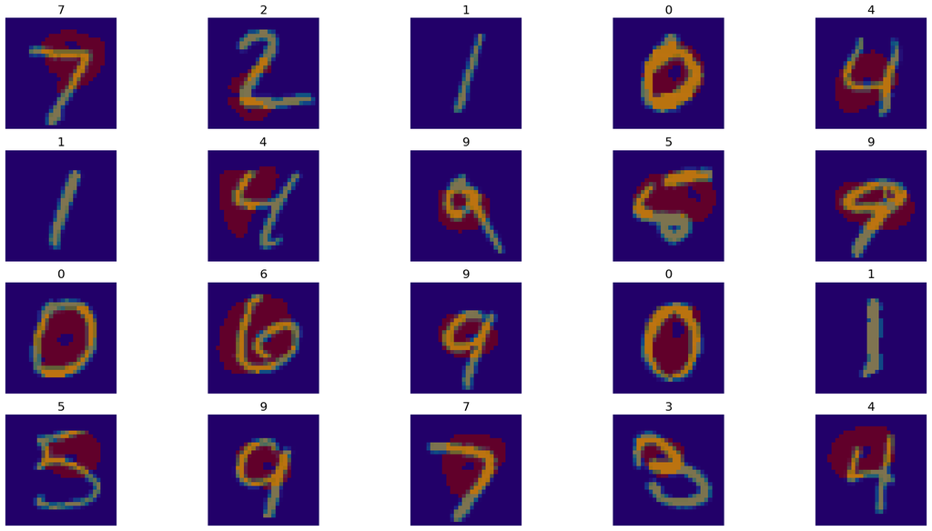

```python
# Creating new ScoreCAM object for testing IoU
scorecam = Scorecam(resnet_model)

# Generate heatmap with ScoreCAM
cam = scorecam(score, X, penultimate_layer=-1)

cam = normalize(cam)

f, ax = plt.subplots(nrows=4, ncols=5, figsize=(20, 10))
ax=ax.flatten()
for i, title in enumerate(img_titles):
    heatmap = np.uint8(cm.jet(cam[i])[..., :1] * 255)
    X_relu=np.squeeze(np.where(X[i]>0.4,1,0))
    heatmap=np.squeeze(np.where(heatmap>=150,255,0))
    res=np.multiply(heatmap,X_relu)
    ax[i].set_title(title, fontsize=16)
    ax[i].imshow(X[i])
    ax[i].imshow(heatmap, cmap='jet', alpha=0.5)
    ax[i].axis('off')
plt.tight_layout()
plt.show()
```

Observations:

- We can clearly see that there are two binary images, i.e., the original image and the red channel of the heatmap, which are overlapped on each other.
- We can also visualize the intersection of these binary images.

Extracting all the correct predictions and storing the scores of the all the images in a list

```python
## Extracting Right Predictions
temp=[]
for i in range(len(y_test)):
  if(y_test[i] == predictions[i]):
    temp.append(i)
```

```python
X_test_right=[]
for i in temp:
  X_test_right.append(x_test[i].reshape(28,28,1))
X_test_right=np.array(X_test_right)
```

```python
y_test_right=[]
for i in temp:
  y_test_right.append(y_test[i])
y_test_right=np.array(y_test_right)
```

```python
score_test_right=CategoricalScore(y_test_right.tolist())
```

Similarly, extracting all the wrong predictions and storing the scores of the all the images in a list

```python
## Extracting Wrong Predictions
temp=[]
for i in range(len(y_test)):
  if(y_test[i] != predictions[i]):
    temp.append(i)
```

```python
X_test_wrong=[]
for i in temp:
  X_test_wrong.append(x_test[i].reshape(28,28,1))
X_test_wrong=np.array(X_test_wrong)
```

```python
y_test_wrong=[]
for i in temp:
  y_test_wrong.append(y_test[i])
y_test_wrong=np.array(y_test_wrong)
```

```python
score_test_wrong=CategoricalScore(y_test_wrong.tolist())
```

```python
# Calculating IoU
def calc_IOU(cam,image):
  heatmap = np.uint8(cm.jet(cam)[..., :1] * 255)
  X_relu=np.squeeze(np.where(image>0.4,1,0))
  heatmap=np.squeeze(np.where(heatmap>=150,255,0))
  IA=np.count_nonzero(heatmap>0)
  res=np.multiply(heatmap,X_relu)
  GTB=np.count_nonzero(X_relu > 0)
  CA=np.count_nonzero(res > 0)
  per=CA*100/(GTB+IA-CA)
  return per
```

Analyzing the IoU scores for each interpretable method w.r.t. correct and wrong predictions

#### GRADCAM

```python
%%time
# Generate heatmap with GradCAM
cam_iou_gc_r = gradcam(score_test_right,
              X_test_right,
              penultimate_layer=-1)

cam_iou_gc_r = normalize(cam_iou_gc_r)
IOU=[]
for i in range(len(X_test_right)):
  IOU.append(calc_IOU(cam_iou_gc_r[i],X_test_right[i]))
Avg=round(sum(IOU)/len(IOU),3)
print("Avg IoU for correct_prediction:",Avg)
```

```
Avg IoU for correct_prediction: 29.438
CPU times: user 18.7 s, sys: 713 ms, total: 19.4 s
Wall time: 23.7 s
```

```python
%%time
# Generate heatmap with GradCAM
cam_iou_gc_wr = gradcam(score_test_wrong,
              X_test_wrong,
              penultimate_layer=-1)

cam_iou_gc_wr = normalize(cam_iou_gc_wr)
IOU=[]
for i in range(len(X_test_wrong)):
  IOU.append(calc_IOU(cam_iou_gc_wr[i],X_test_wrong[i]))
Avg=round(sum(IOU)/len(IOU),3)
print("Avg IoU for wrong prediction:",Avg)
```

```
Avg IoU for wrong prediction: 19.343
CPU times: user 523 ms, sys: 3.89 ms, total: 527 ms
Wall time: 525 ms
```

#### GRADCAM++

```python
%%time
# Generate heatmap with GradCAM
cam_iou_gcpp_r = gradcam_pp(score_test_right,
              X_test_right,
              penultimate_layer=-1)

cam_iou_gcpp_r = normalize(cam_iou_gcpp_r)
IOU=[]
for i in range(len(X_test_right)):
  IOU.append(calc_IOU(cam_iou_gcpp_r[i],X_test_right[i]))
Avg=round(sum(IOU)/len(IOU),3)
print("Avg IoU for correct_prediction:",Avg)
```

```
Avg IoU for correct_prediction: 29.908
CPU times: user 10.5 s, sys: 35 ms, total: 10.5 s
Wall time: 11 s
```

```python
%%time
# Generate heatmap with GradCAM
cam_iou_gcpp_wr = gradcam_pp(score_test_wrong,
              X_test_wrong,
              penultimate_layer=-1)

cam_iou_gcpp_wr = normalize(cam_iou_gcpp_wr)
IOU=[]
for i in range(len(X_test_wrong)):
  IOU.append(calc_IOU(cam_iou_gcpp_wr[i],X_test_wrong[i]))
Avg=round(sum(IOU)/len(IOU),3)
print("Avg IoU for wrong prediction:",Avg)
```

```
Avg IoU for wrong prediction: 21.677
CPU times: user 228 ms, sys: 0 ns, total: 228 ms
Wall time: 267 ms
```

#### SCORECAM

```python
%%time
# Generate heatmap with ScoreCAM
cam_iou_sc_r = scorecam(score_test_right, X_test_right, penultimate_layer=-1)


cam_iou_sc_r = normalize(cam_iou_sc_r)
IOU=[]
for i in range(len(X_test_right)):
  IOU.append(calc_IOU(cam_iou_sc_r[i],X_test_right[i]))
Avg=round(sum(IOU)/len(IOU),3)
print("Avg IoU for correct prediction:",Avg)
```

```
Avg IoU for correct prediction: 26.816
CPU times: user 3min 16s, sys: 5.32 s, total: 3min 22s
Wall time: 3min 23s
```

```python
%%time
# Generate heatmap with ScoreCAM
cam_iou_sc_wr = scorecam(score_test_wrong, X_test_wrong, penultimate_layer=-1)


cam_iou_sc_wr = normalize(cam_iou_sc_wr)
IOU=[]
for i in range(len(X_test_wrong)):
  IOU.append(calc_IOU(cam_iou_sc_wr[i],X_test_wrong[i]))
Avg=round(sum(IOU)/len(IOU),3)
print("Avg IoU for wrong prediction:",Avg)
```

```
Avg IoU for wrong prediction: 21.702
CPU times: user 2.37 s, sys: 56.3 ms, total: 2.43 s
Wall time: 2.55 s
```

#### FASTER SCORECAM

```python
%%time
# Generate heatmap with Faster-ScoreCAM
cam_iou_fsc_r = faster_scorecam(score_test_right,
               X_test_right,
               penultimate_layer=-1,
               max_N=10)
cam_iou_fsc_r = normalize(cam_iou_fsc_r)

IOU=[]
for i in range(len(X_test_right)):
  IOU.append(calc_IOU(cam_iou_fsc_r[i],X_test_right[i]))
Avg=round(sum(IOU)/len(IOU),3)
print("Avg IoU for correct prediction:",Avg)
```

```
Avg IoU for correct prediction: 27.03
CPU times: user 3min 26s, sys: 5.46 s, total: 3min 31s
Wall time: 3min 50s
```

```python
%%time
# Generate heatmap with Faster-ScoreCAM
cam_iou_fsc_wr = faster_scorecam(score_test_wrong,
               X_test_wrong,
               penultimate_layer=-1,
               max_N=10)
cam_iou_fsc_wr = normalize(cam_iou_fsc_wr)
IOU=[]
for i in range(len(X_test_wrong)):
  IOU.append(calc_IOU(cam_iou_fsc_wr[i],X_test_wrong[i]))
Avg=round(sum(IOU)/len(IOU),3)
print("Avg IoU for wrong prediction:",Avg)
```

```
Avg IoU for wrong prediction: 22.554
CPU times: user 2.91 s, sys: 53.9 ms, total: 2.96 s
Wall time: 3 s
```

#### Comparison of Interpretable methods w.r.t IoU scores:

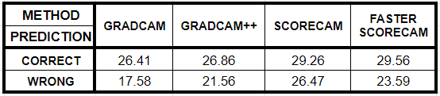

**Note: The above values are taken from an earlier execution**

### Conclusion:

Our efforts to enhance the interpretability of our machine learning model involved the implementation and evaluation of both gradient-based and gradient-free visualization algorithms. These techniques allowed us to delve deep into the inner workings of the model and gain valuable insights into how it makes decisions. By visualizing the gradients and activation patterns, we were able to identify important features and understand the reasoning behind the model's predictions.

Moving forward, we recognize the need to generalize our evaluation metrics, especially for multichannel images. Multichannel images, such as RGB images, contain multiple layers of information that can significantly impact the model's performance. By developing and applying more comprehensive evaluation metrics tailored to these types of data, we aim to gain a more nuanced understanding of our model's performance across different datasets.

This broader perspective will not only help us refine our interpretability assessments but also enable us to uncover potential biases or limitations in our model. By addressing these issues, we can further improve the robustness and reliability of our machine learning model.

### References:

- [tf-keras-vis documentation](https://keisen.github.io/tf-keras-vis-docs/)
- [Saliency paper](https://arxiv.org/pdf/1312.6034)
- [GRADCAM paper](https://arxiv.org/pdf/1610.02391v1)
- [SCORECAM paper](https://arxiv.org/pdf/1910.01279)
- [Intersection over Union](https://www.superannotate.com/blog/intersection-over-union-for-object-detection#what-is-intersection-over-union-iou)